# DEFENSIVE TRAITS C.arvensis SIBECOL 2025

Andrés Delgado Galán

2025-05-18

### C.arvensis - PRODUCCIÓN DE FLORES

**flor ~ trat + clip + trat:clip**  
n = **36**

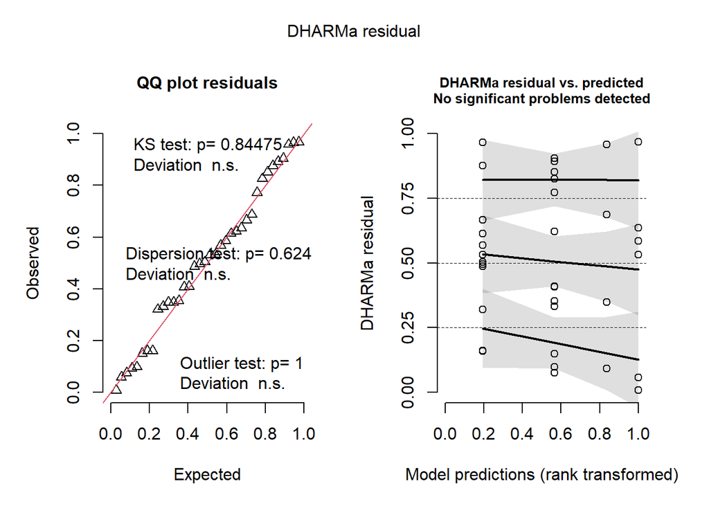

##### CAflor Post-hoc Comparisons with Tukeys HSD

| contrast | trat | estimate | SE | df | z.ratio | p.value |
| --- | --- | --- | --- | --- | --- | --- |
| no - yes | ex | 0.4432031 | 0.3280049 | Inf | 1.3512087 | 0.1766286 |
| no - yes | gra | 0.0599916 | 0.4789564 | Inf | 0.1252549 | 0.9003218 |

| contrast | clip | estimate | SE | df | z.ratio | p.value |
| --- | --- | --- | --- | --- | --- | --- |
| ex - gra | no | -0.2373674 | 0.3915854 | Inf | -0.6061701 | 0.5444018 |
| ex - gra | yes | -0.6205788 | 0.4285409 | Inf | -1.4481205 | 0.1475833 |

ANOVA Results for CAflor Model

| Response | Predictor | Chisq | Df | Pr(>Chisq) |
| --- | --- | --- | --- | --- |
| CA flor | trat | 2.029 | 1 | 0.154 |
| CA flor | clip | 1.406 | 1 | 0.236 |
| CA flor | trat:clip | 0.436 | 1 | 0.509 |

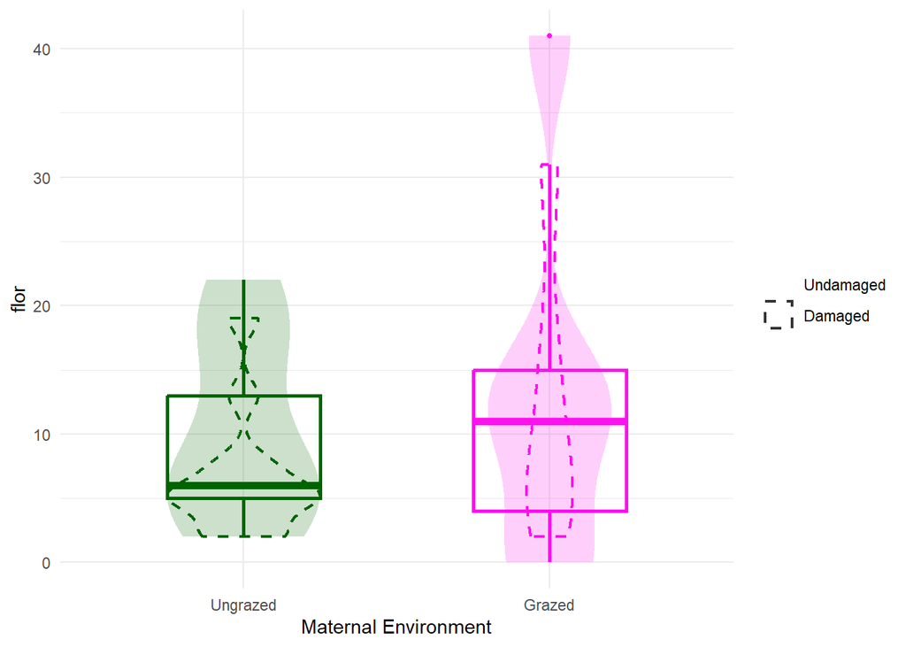

### C.arvensis - PRODUCCIÓN DE FRUTOS

**fruto ~ trat + clip + trat:clip**  
n = **36**

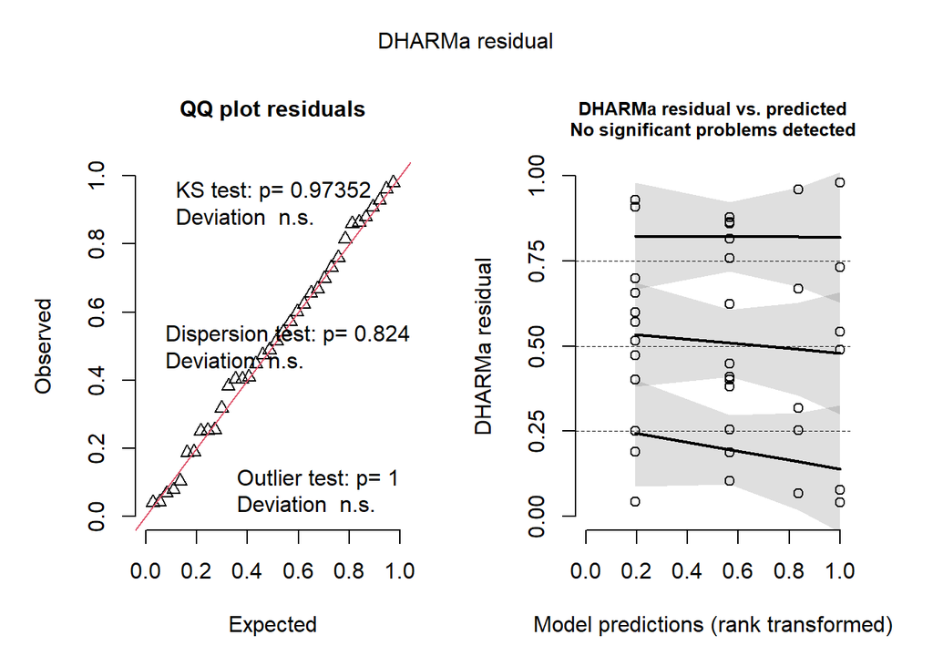

##### CAfruto Post-hoc Comparisons with Tukeys HSD

| contrast | trat | estimate | SE | df | z.ratio | p.value |
| --- | --- | --- | --- | --- | --- | --- |
| no - yes | ex | 0.4863503 | 0.3611423 | Inf | 1.3466999 | 0.1780769 |
| no - yes | gra | 0.0447381 | 0.5260344 | Inf | 0.0850479 | 0.9322233 |

| contrast | clip | estimate | SE | df | z.ratio | p.value |
| --- | --- | --- | --- | --- | --- | --- |
| ex - gra | no | -0.2225446 | 0.4301830 | Inf | -0.5173253 | 0.6049291 |
| ex - gra | yes | -0.6641567 | 0.4712521 | Inf | -1.4093451 | 0.1587332 |

ANOVA Results for CAfruto Model

| Response | Predictor | Chisq | Df | Pr(>Chisq) |
| --- | --- | --- | --- | --- |
| CA fruto | trat | 1.775 | 1 | 0.183 |
| CA fruto | clip | 1.342 | 1 | 0.247 |
| CA fruto | trat:clip | 0.479 | 1 | 0.489 |

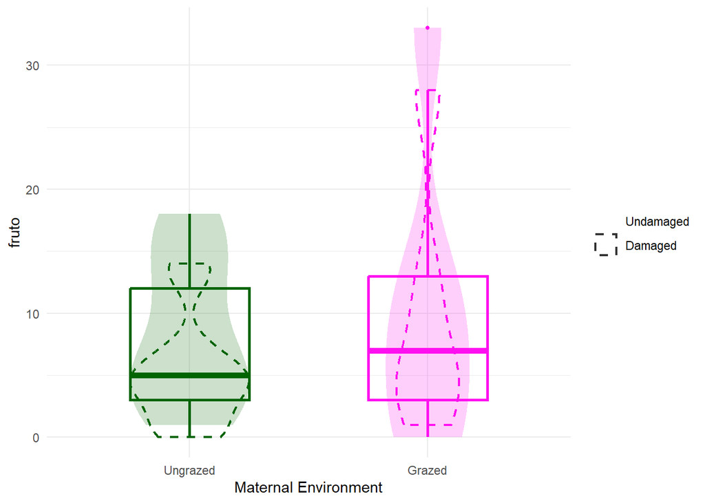

### C.arvensis - PRODUCCIÓN DE HOJAS

**hojas ~ trat + clip + trat:clip**  
n = **36**

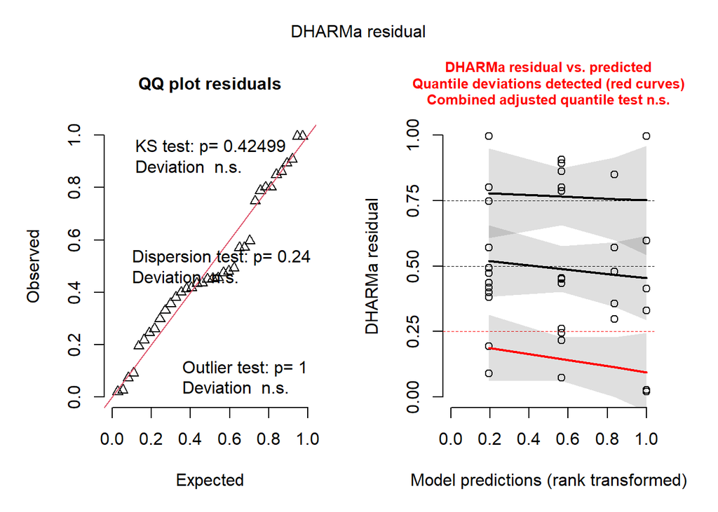

##### CAhojas Post-hoc Comparisons with Tukeys HSD

| contrast | trat | estimate | SE | df | z.ratio | p.value |
| --- | --- | --- | --- | --- | --- | --- |
| no - yes | ex | 0.1971554 | 0.1780347 | Inf | 1.107399 | 0.2681216 |
| no - yes | gra | 0.0535244 | 0.2672413 | Inf | 0.200285 | 0.8412577 |

| contrast | clip | estimate | SE | df | z.ratio | p.value |
| --- | --- | --- | --- | --- | --- | --- |
| ex - gra | no | -0.1837764 | 0.2180039 | Inf | -0.8429957 | 0.3992309 |
| ex - gra | yes | -0.3274073 | 0.2357722 | Inf | -1.3886594 | 0.1649363 |

ANOVA Results for CAhojas Model

| Response | Predictor | Chisq | Df | Pr(>Chisq) |
| --- | --- | --- | --- | --- |
| CA hojas | trat | 2.439 | 1 | 0.118 |
| CA hojas | clip | 1.066 | 1 | 0.302 |
| CA hojas | trat:clip | 0.200 | 1 | 0.655 |

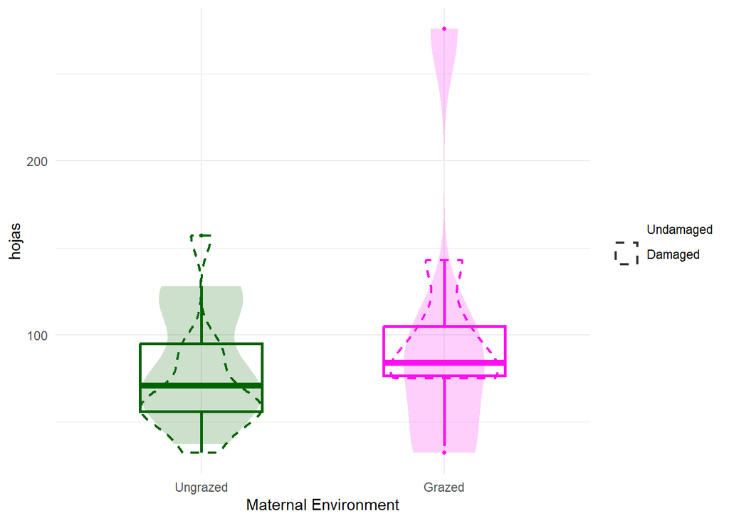

### C.arvensis - ALTURA MÁXIMA

**altura ~ trat + clip + trat:clip**  
n = **37**

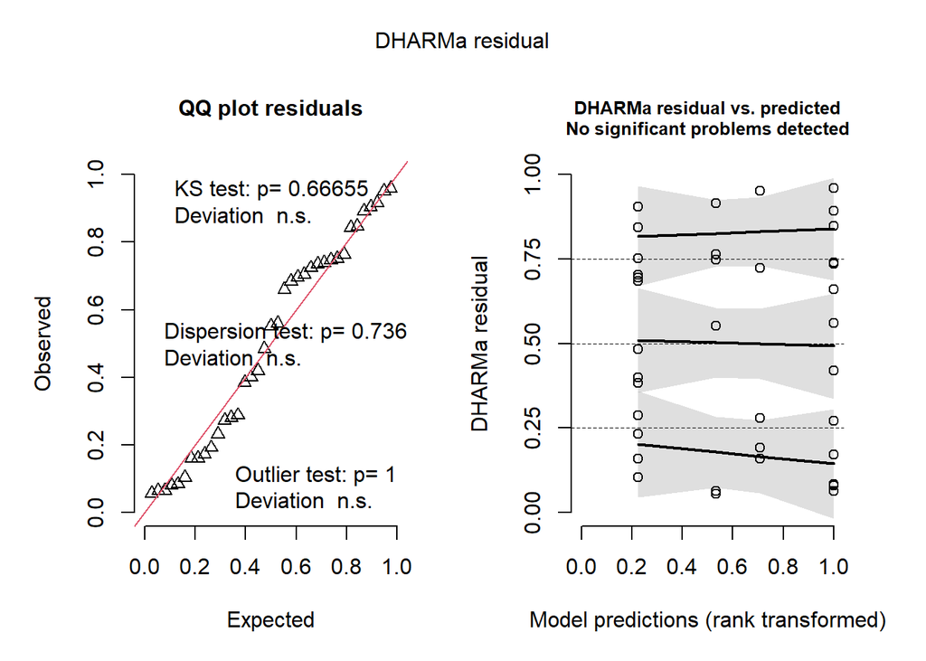

R² = **-0.008074**

##### CAaltura Post-hoc Comparisons with Tukeys HSD

| contrast | trat | estimate | SE | df | t.ratio | p.value |
| --- | --- | --- | --- | --- | --- | --- |
| no - yes | ex | 6.5230769 | 3.965101 | 33 | 1.6451225 | 0.1094382 |
| no - yes | gra | -0.0166667 | 6.121342 | 33 | -0.0027227 | 0.9978440 |

| contrast | clip | estimate | SE | df | t.ratio | p.value |
| --- | --- | --- | --- | --- | --- | --- |
| ex - gra | no | 3.532051 | 4.989309 | 33 | 0.7079239 | 0.4839629 |
| ex - gra | yes | -3.007692 | 5.319741 | 33 | -0.5653832 | 0.5756373 |

ANOVA Results for CAaltura Model

| Response | Predictor | Sum Sq | Df | F value | Pr(>F) |
| --- | --- | --- | --- | --- | --- |
| CA altura | trat | 1.716 | 1 | 0.017 | 0.898 |
| CA altura | clip | 194.414 | 1 | 1.902 | 0.177 |
| CA altura | trat:clip | 82.166 | 1 | 0.804 | 0.376 |
| CA altura | Residuals | 3372.374 | 33 | NA | NA |

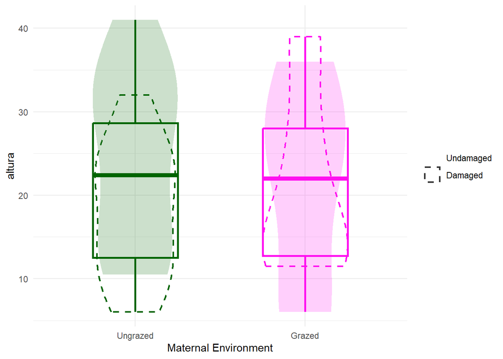

### C.arvensis - SEMILLAS/FRUTO

**seedfruto ~ trat + clip + trat:clip**  
n = **30**

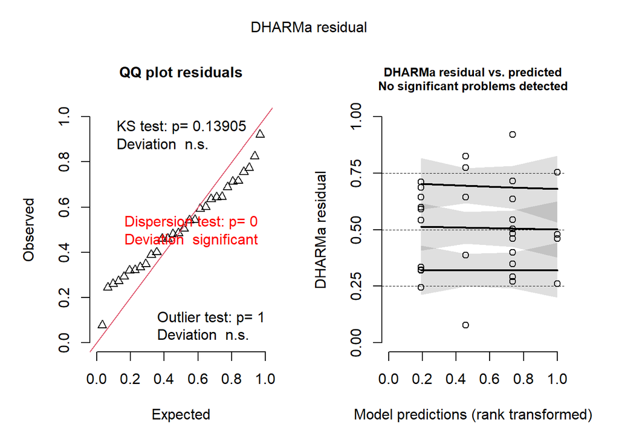

##### CAseedfruto Post-hoc Comparisons with Tukeys HSD

| contrast | trat | estimate | SE | df | z.ratio | p.value |
| --- | --- | --- | --- | --- | --- | --- |
| no - yes | ex | 0.0292781 | 0.1142170 | Inf | 0.2563377 | 0.7976901 |
| no - yes | gra | 0.0360216 | 0.1747276 | Inf | 0.2061583 | 0.8366672 |

| contrast | clip | estimate | SE | df | z.ratio | p.value |
| --- | --- | --- | --- | --- | --- | --- |
| ex - gra | no | -0.0079206 | 0.1510161 | Inf | -0.0524487 | 0.9581712 |
| ex - gra | yes | -0.0011772 | 0.1441159 | Inf | -0.0081682 | 0.9934828 |

ANOVA Results for CAseedfruto Model

| Response | Predictor | Chisq | Df | Pr(>Chisq) |
| --- | --- | --- | --- | --- |
| CA seedfruto | trat | 0.002 | 1 | 0.966 |
| CA seedfruto | clip | 0.107 | 1 | 0.743 |
| CA seedfruto | trat:clip | 0.001 | 1 | 0.974 |

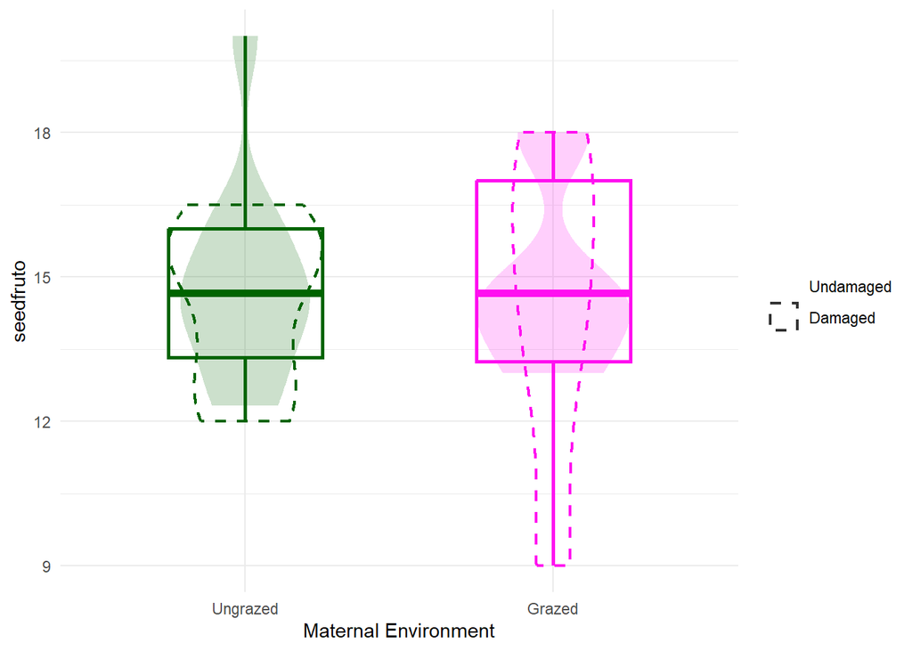

### C.arvensis - PRODUCCIÓN DE SEMILLAS

**seedtotal ~ trat + clip + trat:clip**  
n = **37**

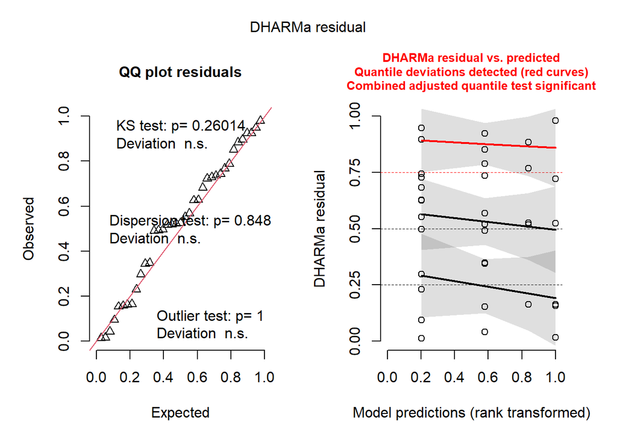

##### CAseedtotal Post-hoc Comparisons with Tukeys HSD

| contrast | trat | estimate | SE | df | z.ratio | p.value |
| --- | --- | --- | --- | --- | --- | --- |
| no - yes | ex | 0.504767 | 0.4215121 | Inf | 1.1975148 | 0.2311059 |
| no - yes | gra | 0.030926 | 0.6498053 | Inf | 0.0475927 | 0.9620409 |

| contrast | clip | estimate | SE | df | z.ratio | p.value |
| --- | --- | --- | --- | --- | --- | --- |
| ex - gra | no | -0.0643908 | 0.5296428 | Inf | -0.1215741 | 0.9032363 |
| ex - gra | yes | -0.5382318 | 0.5651530 | Inf | -0.9523648 | 0.3409120 |

ANOVA Results for CAseedtotal Model

| Response | Predictor | Chisq | Df | Pr(>Chisq) |
| --- | --- | --- | --- | --- |
| CA seedtotal | trat | 0.548 | 1 | 0.459 |
| CA seedtotal | clip | 1.062 | 1 | 0.303 |
| CA seedtotal | trat:clip | 0.374 | 1 | 0.541 |

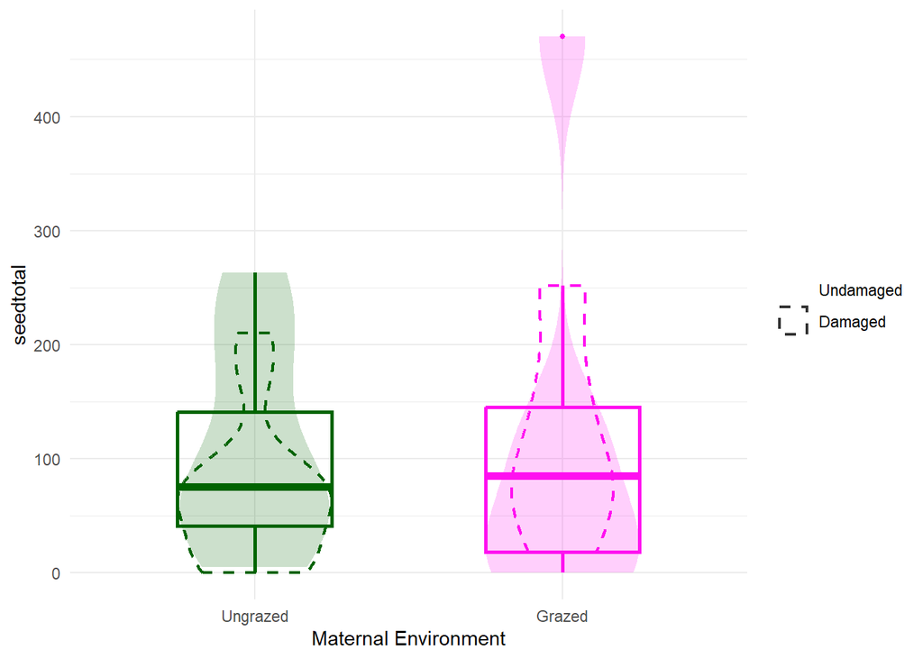

### C.arvensis - PESO MEDIO DE LAS SEMILLAS

**massseed ~ trat + clip + trat:clip**  
n = **36**

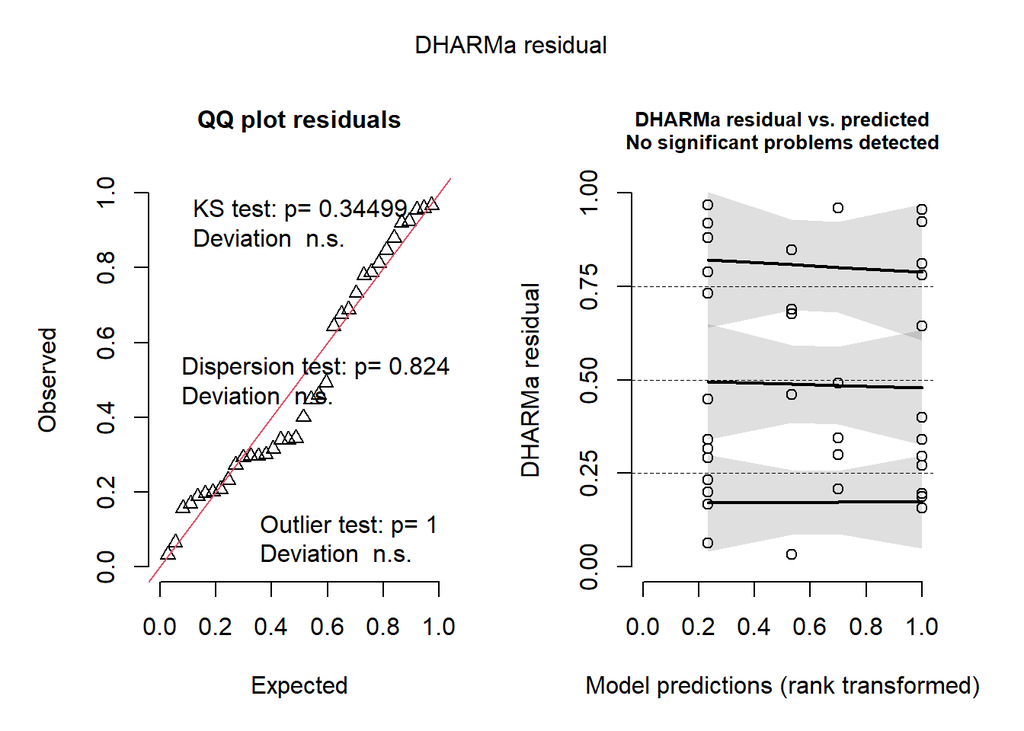

R² = **-0.022086**

##### CAmassseed Post-hoc Comparisons with Tukeys HSD

| contrast | trat | estimate | SE | df | t.ratio | p.value |
| --- | --- | --- | --- | --- | --- | --- |
| no - yes | ex | 0.00110 | 0.0007541 | 32 | 1.458614 | 0.1544177 |
| no - yes | gra | -0.00036 | 0.0012160 | 32 | -0.296049 | 0.7691055 |

| contrast | clip | estimate | SE | df | t.ratio | p.value |
| --- | --- | --- | --- | --- | --- | --- |
| ex - gra | no | 0.0008508 | 0.0010118 | 32 | 0.8408592 | 0.4066663 |
| ex - gra | yes | -0.0006092 | 0.0010118 | 32 | -0.6021343 | 0.5513278 |

ANOVA Results for CAmassseed Model

| Response | Predictor | Sum Sq | Df | F value | Pr(>F) |
| --- | --- | --- | --- | --- | --- |
| CA massseed | trat | 0 | 1 | 0.028 | 0.867 |
| CA massseed | clip | 0 | 1 | 1.174 | 0.287 |
| CA massseed | trat:clip | 0 | 1 | 1.041 | 0.315 |
| CA massseed | Residuals | 0 | 32 | NA | NA |

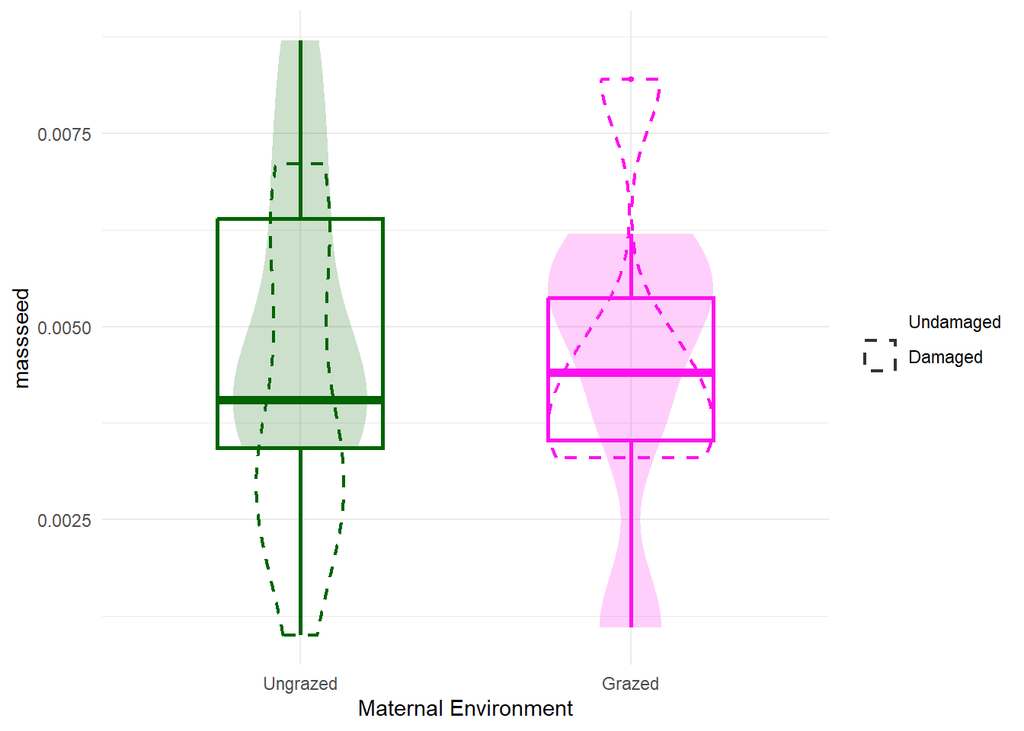

### C.arvensis - SLA

**SLA ~ trat + clip + trat:clip**  
n = **33**

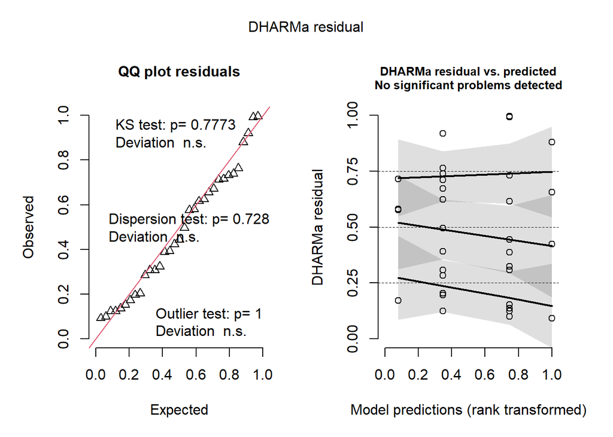

R² = **0.0272141**

##### CASLA Post-hoc Comparisons with Tukeys HSD

| contrast | trat | estimate | SE | df | t.ratio | p.value |
| --- | --- | --- | --- | --- | --- | --- |
| no - yes | ex | -67.96454 | 49.85895 | 29 | -1.363136 | 0.1833303 |
| no - yes | gra | -120.81250 | 88.06847 | 29 | -1.371802 | 0.1806454 |

| contrast | clip | estimate | SE | df | t.ratio | p.value |
| --- | --- | --- | --- | --- | --- | --- |
| ex - gra | no | 47.716097 | 71.21283 | 29 | 0.6700491 | 0.5081273 |
| ex - gra | yes | -5.131862 | 71.90761 | 29 | -0.0713674 | 0.9435952 |

ANOVA Results for CASLA Model

| Response | Predictor | Sum Sq | Df | F value | Pr(>F) |
| --- | --- | --- | --- | --- | --- |
| CA SLA | trat | 2813.383 | 1 | 0.181 | 0.673 |
| CA SLA | clip · | 53784.967 | 1 | 3.467 | 0.073 |
| CA SLA | trat:clip | 4230.034 | 1 | 0.273 | 0.605 |
| CA SLA | Residuals | 449851.246 | 29 | NA | NA |

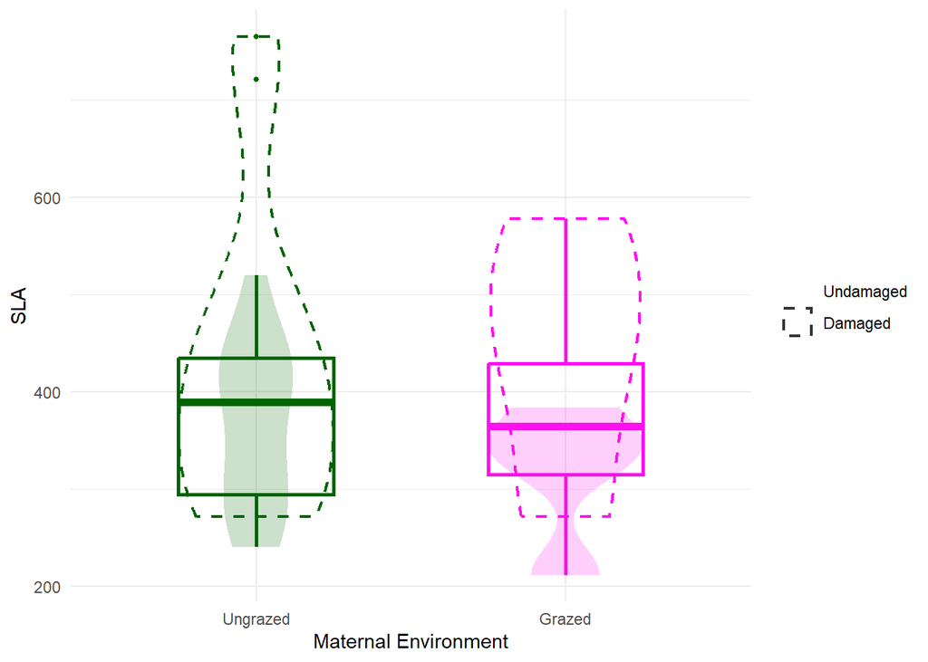

### C.arvensis - LDMC

**LDMC ~ trat + clip + trat:clip**  
n = **31**

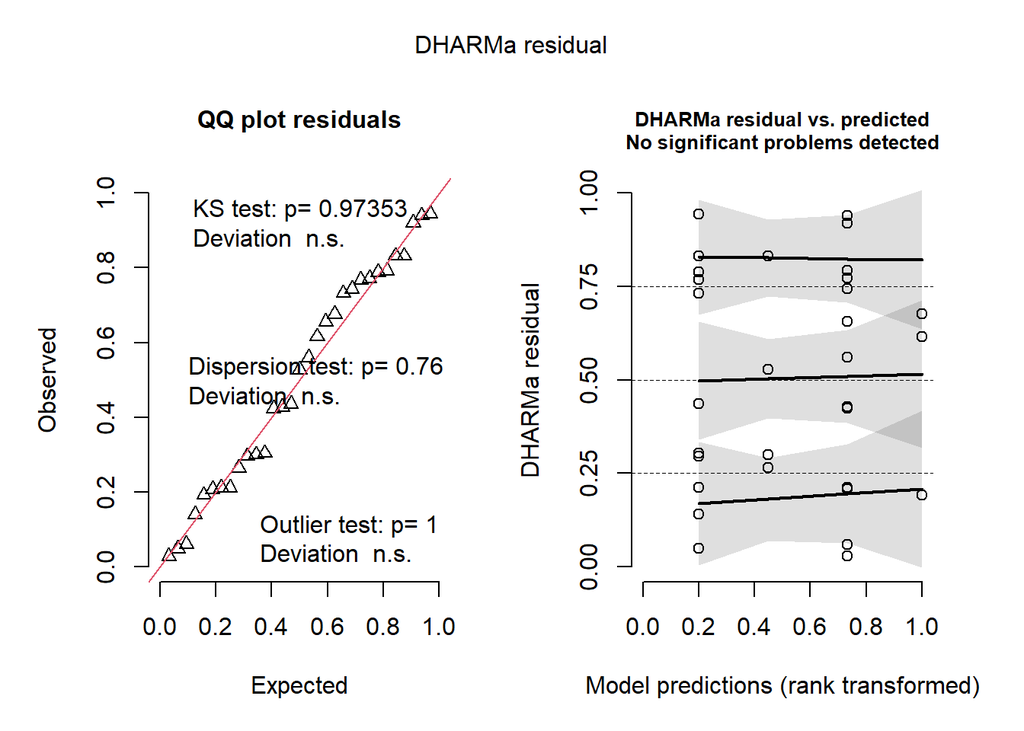

R² = **0.003613**

##### CALDMC Post-hoc Comparisons with Tukeys HSD

| contrast | trat | estimate | SE | df | t.ratio | p.value |
| --- | --- | --- | --- | --- | --- | --- |
| no - yes | ex | 0.0111707 | 0.0071686 | 27 | 1.5582977 | 0.1308083 |
| no - yes | gra | 0.0109952 | 0.0133645 | 27 | 0.8227209 | 0.4178740 |

| contrast | clip | estimate | SE | df | t.ratio | p.value |
| --- | --- | --- | --- | --- | --- | --- |
| ex - gra | no | -0.0016154 | 0.0112078 | 27 | -0.1441278 | 0.8864699 |
| ex - gra | yes | -0.0017909 | 0.0102168 | 27 | -0.1752863 | 0.8621626 |

ANOVA Results for CALDMC Model

| Response | Predictor | Sum Sq | Df | F value | Pr(>F) |
| --- | --- | --- | --- | --- | --- |
| CA LDMC | trat | 0.000 | 1 | 0.051 | 0.822 |
| CA LDMC | clip · | 0.001 | 1 | 3.105 | 0.089 |
| CA LDMC | trat:clip | 0.000 | 1 | 0.000 | 0.991 |
| CA LDMC | Residuals | 0.008 | 27 | NA | NA |

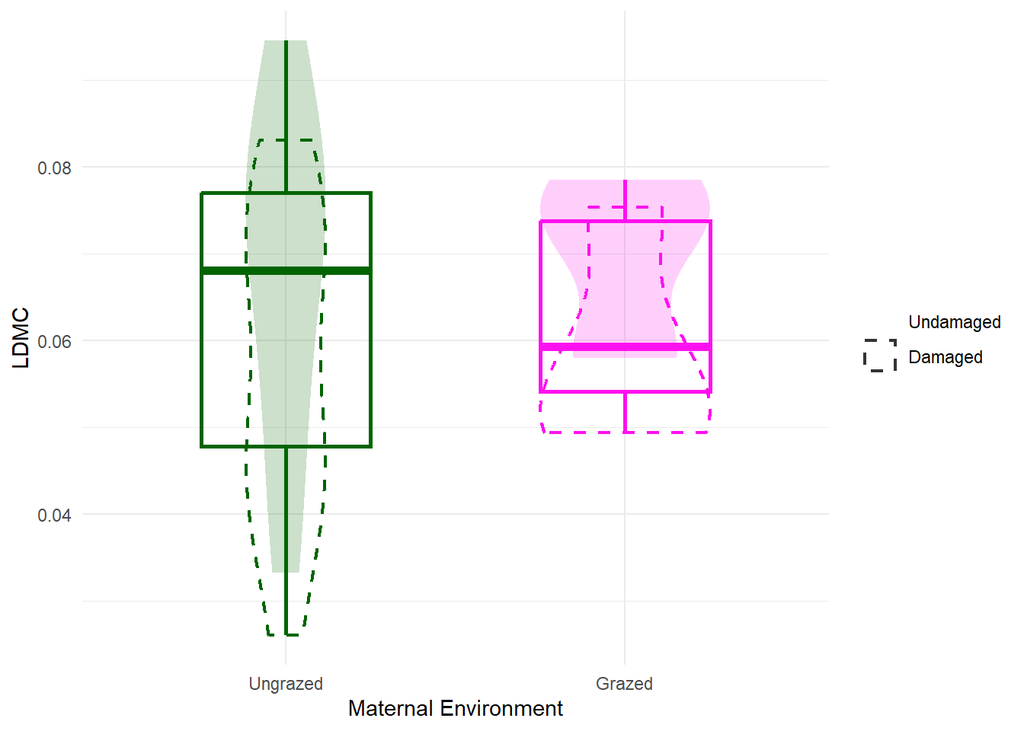

### C.arvensis - ÁREA FOLIAR

**area.m ~ trat + clip + trat:clip**  
n = **33**

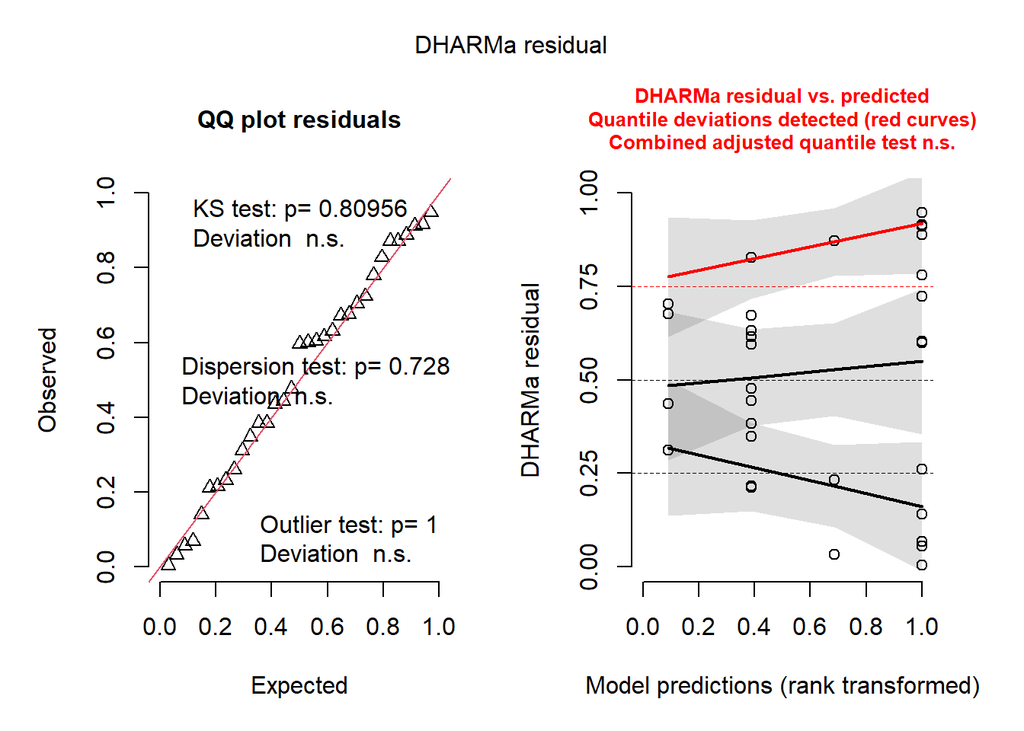

R² = **0.2740142**

##### CAarea.m Post-hoc Comparisons with Tukeys HSD

| contrast | trat | estimate | SE | df | t.ratio | p.value |
| --- | --- | --- | --- | --- | --- | --- |
| no - yes | ex | 3.066218 | 0.8843661 | 29 | 3.467137 | 0.0016618 |
| no - yes | gra | 2.432250 | 1.5621019 | 29 | 1.557037 | 0.1303091 |

| contrast | clip | estimate | SE | df | t.ratio | p.value |
| --- | --- | --- | --- | --- | --- | --- |
| ex - gra | no | 0.9693846 | 1.263127 | 29 | 0.7674480 | 0.4490189 |
| ex - gra | yes | 0.3354167 | 1.275451 | 29 | 0.2629789 | 0.7944263 |

ANOVA Results for CAarea.m Model

| Response | Predictor | Sum Sq | Df | F value | Pr(>F) |
| --- | --- | --- | --- | --- | --- |
| CA area.m | trat | 2.603 | 1 | 0.533 | 0.471 |
| CA area.m | clip *** | 69.890 | 1 | 14.321 | 0.001 |
| CA area.m | trat:clip | 0.609 | 1 | 0.125 | 0.727 |
| CA area.m | Residuals | 141.529 | 29 | NA | NA |

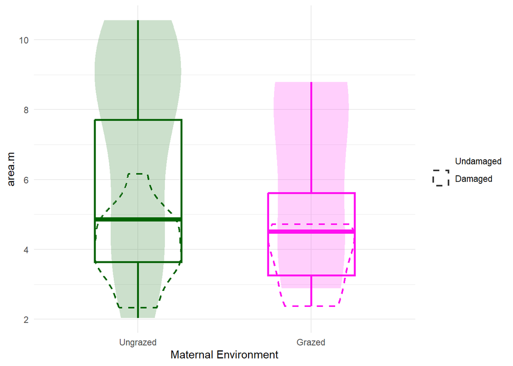

### C.arvensis - FENOLOGÍA DE FLORACIÓN

**dias_flor ~ trat + clip + trat:clip**  
n = **33**

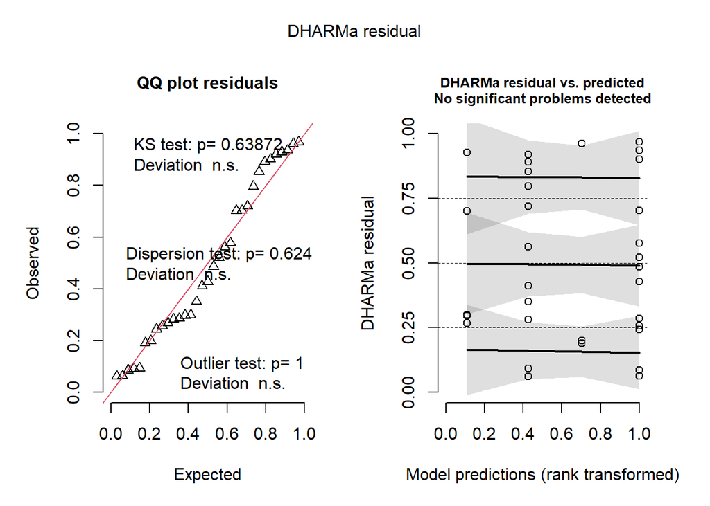

##### CAdias_flor Post-hoc Comparisons with Tukeys HSD

| contrast | trat | estimate | SE | df | z.ratio | p.value |
| --- | --- | --- | --- | --- | --- | --- |
| no - yes | ex | -0.0674196 | 0.1294796 | Inf | -0.5206966 | 0.6025781 |
| no - yes | gra | 0.1255646 | 0.2374388 | Inf | 0.5288294 | 0.5969238 |

| contrast | clip | estimate | SE | df | z.ratio | p.value |
| --- | --- | --- | --- | --- | --- | --- |
| ex - gra | no | -0.0087903 | 0.2091462 | Inf | -0.0420297 | 0.966475 |
| ex - gra | yes | 0.1841938 | 0.1714643 | Inf | 1.0742404 | 0.282715 |

ANOVA Results for CAdias_flor Model

| Response | Predictor | Chisq | Df | Pr(>Chisq) |
| --- | --- | --- | --- | --- |
| CA dias_flor | trat | 0.647 | 1 | 0.421 |
| CA dias_flor | clip | 0.042 | 1 | 0.838 |
| CA dias_flor | trat:clip | 0.509 | 1 | 0.475 |

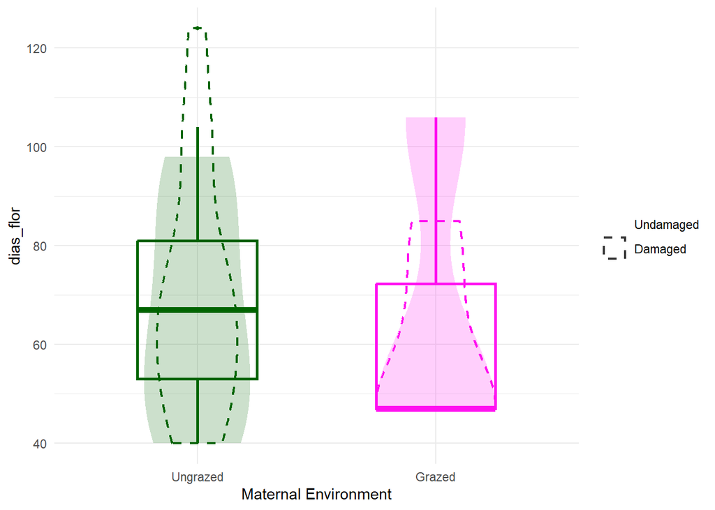

### C.arvensis - FENOLOGÍA DE FRUCTIFICACÓN

**dias_fruto ~ trat + clip + trat:clip**  
n = **34**

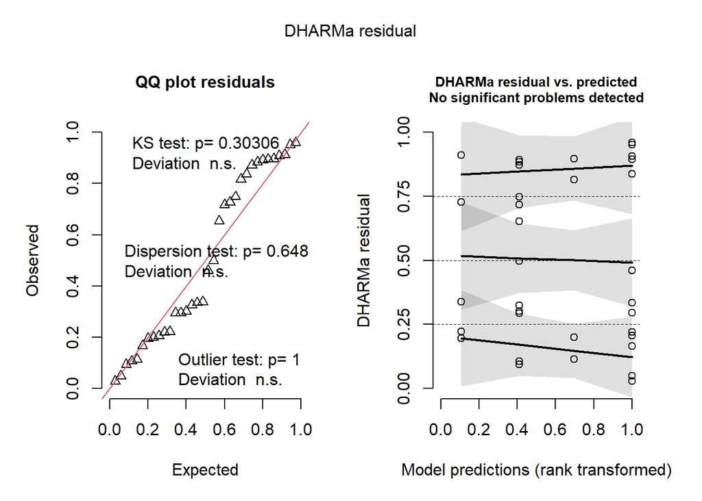

##### CAdias_fruto Post-hoc Comparisons with Tukeys HSD

| contrast | trat | estimate | SE | df | z.ratio | p.value |
| --- | --- | --- | --- | --- | --- | --- |
| no - yes | ex | -0.1104870 | 0.1286219 | Inf | -0.8590059 | 0.3903373 |
| no - yes | gra | 0.1913948 | 0.2171845 | Inf | 0.8812547 | 0.3781800 |

| contrast | clip | estimate | SE | df | z.ratio | p.value |
| --- | --- | --- | --- | --- | --- | --- |
| ex - gra | no | -0.0217398 | 0.1859045 | Inf | -0.1169409 | 0.9069069 |
| ex - gra | yes | 0.2801420 | 0.1707402 | Inf | 1.6407500 | 0.1008493 |

ANOVA Results for CAdias_fruto Model

| Response | Predictor | Chisq | Df | Pr(>Chisq) |
| --- | --- | --- | --- | --- |
| CA dias_fruto | trat | 1.275 | 1 | 0.259 |
| CA dias_fruto | clip | 0.084 | 1 | 0.772 |
| CA dias_fruto | trat:clip | 1.430 | 1 | 0.232 |

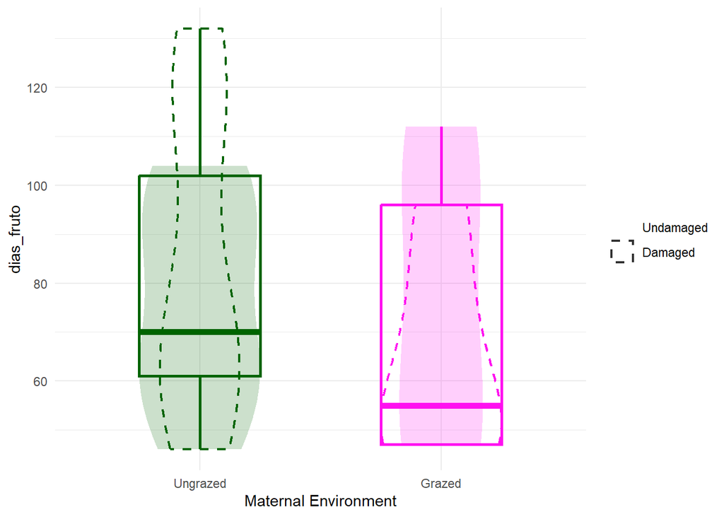

### C.arvensis - PERIODO DE FLORACIÓN

**periodo_flor ~ trat + clip + trat:clip**  
n = **30**

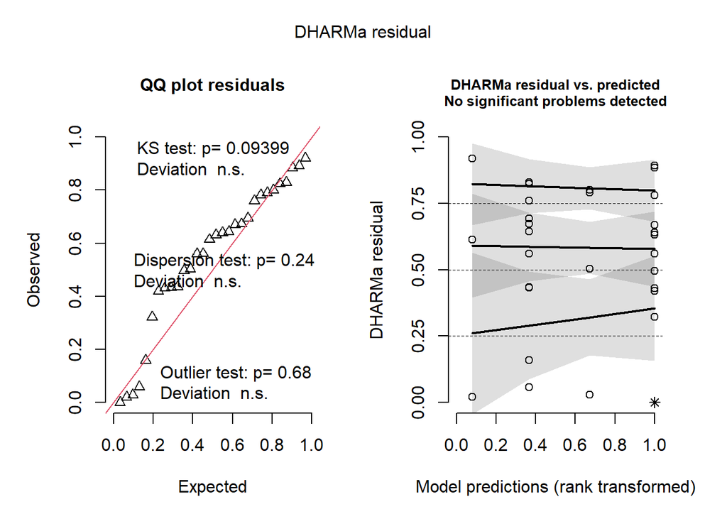

##### CAperiodo_flor Post-hoc Comparisons with Tukeys HSD

| contrast | trat | estimate | SE | df | z.ratio | p.value |
| --- | --- | --- | --- | --- | --- | --- |
| no - yes | ex | 0.1690323 | 0.2300083 | Inf | 0.7348963 | 0.4624026 |
| no - yes | gra | -0.1637198 | 0.4212710 | Inf | -0.3886330 | 0.6975476 |

| contrast | clip | estimate | SE | df | z.ratio | p.value |
| --- | --- | --- | --- | --- | --- | --- |
| ex - gra | no | 0.1932128 | 0.3563717 | Inf | 0.5421665 | 0.5877038 |
| ex - gra | yes | -0.1395393 | 0.3215156 | Inf | -0.4340048 | 0.6642849 |

ANOVA Results for CAperiodo_flor Model

| Response | Predictor | Chisq | Df | Pr(>Chisq) |
| --- | --- | --- | --- | --- |
| CA periodo_flor | trat | 0.002 | 1 | 0.967 |
| CA periodo_flor | clip | 0.210 | 1 | 0.646 |
| CA periodo_flor | trat:clip | 0.481 | 1 | 0.488 |

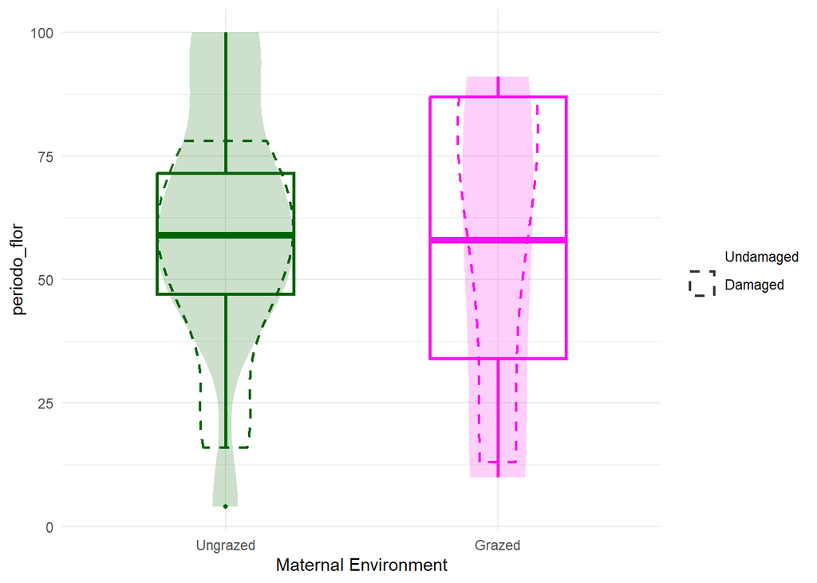

### C.arvensis - PERIODO DE FRUCTIFICACIÓN

**periodo_fruto ~ trat + clip + trat:clip**

n = **33**

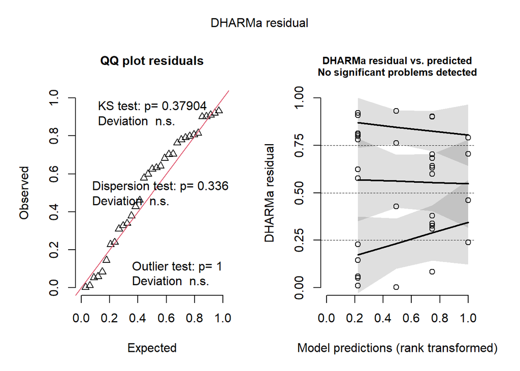

##### CAperiodo_fruto Post-hoc Comparisons with Tukeys HSD

| contrast | trat | estimate | SE | df | z.ratio | p.value |
| --- | --- | --- | --- | --- | --- | --- |
| no - yes | ex | 0.2369706 | 0.2337546 | Inf | 1.013758 | 0.3106982 |
| no - yes | gra | -0.3031867 | 0.4114520 | Inf | -0.736870 | 0.4612014 |

| contrast | clip | estimate | SE | df | z.ratio | p.value |
| --- | --- | --- | --- | --- | --- | --- |
| ex - gra | no | 0.1376465 | 0.3369669 | Inf | 0.4084867 | 0.6829164 |
| ex - gra | yes | -0.4025108 | 0.3322458 | Inf | -1.2114850 | 0.2257096 |

ANOVA Results for CAperiodo_fruto Model

| Response | Predictor | Chisq | Df | Pr(>Chisq) |
| --- | --- | --- | --- | --- |
| CA periodo_fruto | trat | 0.332 | 1 | 0.565 |
| CA periodo_fruto | clip | 0.268 | 1 | 0.605 |
| CA periodo_fruto | trat:clip | 1.303 | 1 | 0.254 |

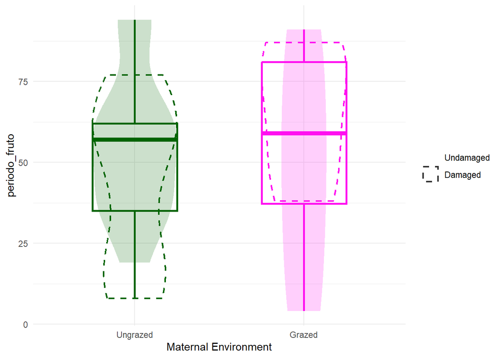

### C.arvensis - dias_fin DE FLORACIÓN

**dias_fin_flor ~ trat + clip + trat:clip**  
n = **32**

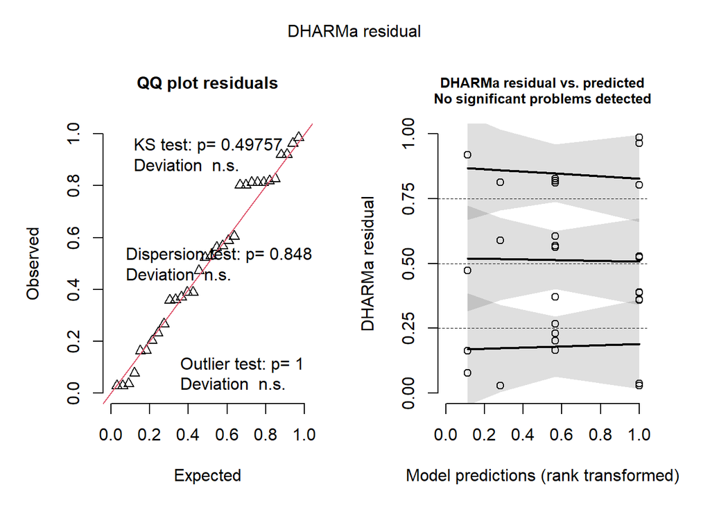

##### CAdias_fin_flor Post-hoc Comparisons with Tukeys HSD

| contrast | trat | estimate | SE | df | z.ratio | p.value |
| --- | --- | --- | --- | --- | --- | --- |
| no - yes | ex | 0.0154859 | 0.0478499 | Inf | 0.3236343 | 0.7462149 |
| no - yes | gra | -0.0414998 | 0.0782840 | Inf | -0.5301183 | 0.5960299 |

| contrast | clip | estimate | SE | df | z.ratio | p.value |
| --- | --- | --- | --- | --- | --- | --- |
| ex - gra | no | 0.0904190 | 0.0620627 | Inf | 1.4568967 | 0.1451449 |
| ex - gra | yes | 0.0334333 | 0.0675738 | Inf | 0.4947681 | 0.6207638 |

ANOVA Results for CAdias_fin_flor Model

| Response | Predictor | Chisq | Df | Pr(>Chisq) |
| --- | --- | --- | --- | --- |
| CA dias_fin_flor | trat | 1.982 | 1 | 0.159 |
| CA dias_fin_flor | clip | 0.000 | 1 | 1.000 |
| CA dias_fin_flor | trat:clip | 0.386 | 1 | 0.535 |

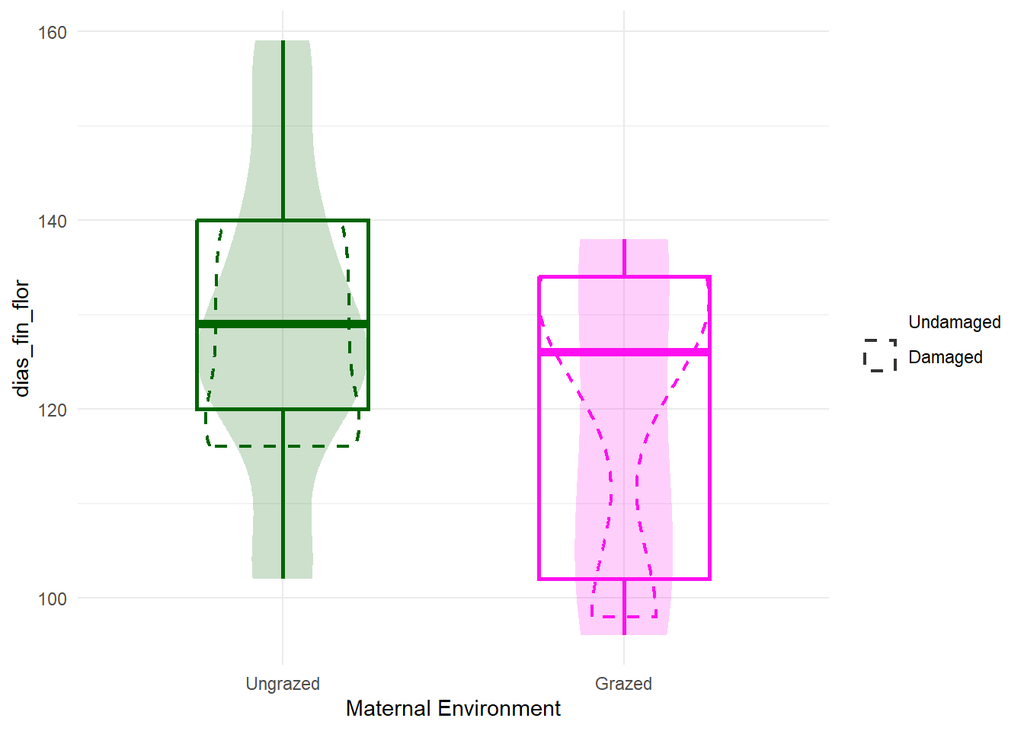

### C.arvensis - dias_fin DE FRUCTIFICACIÓN

**dias_fin_fruto ~ trat + clip + trat:clip**

n = **36**

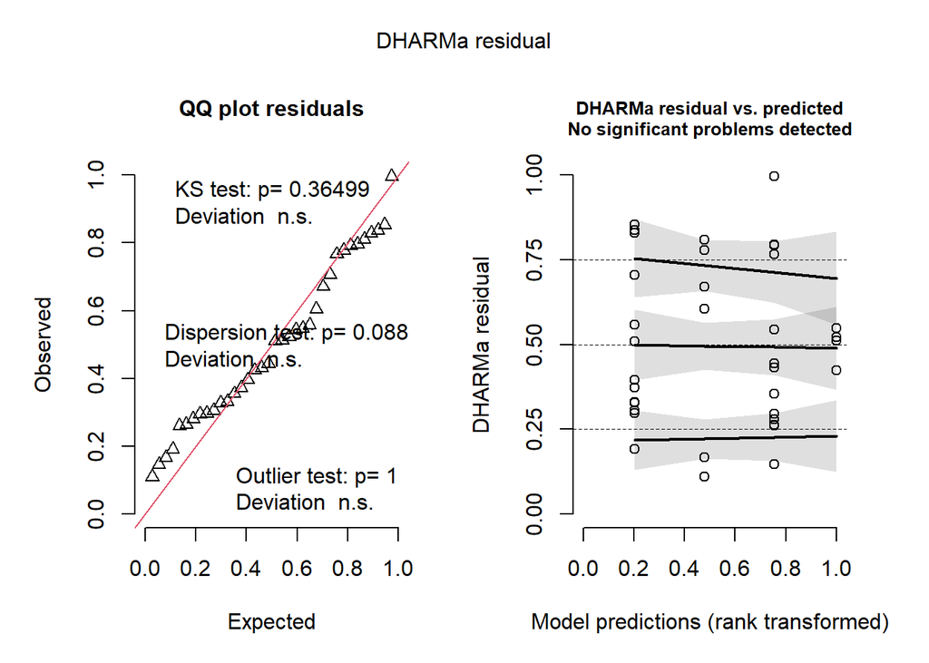

##### CAdias_fin_fruto Post-hoc Comparisons with Tukeys HSD

| contrast | trat | estimate | SE | df | z.ratio | p.value |
| --- | --- | --- | --- | --- | --- | --- |
| no - yes | ex | 0.0219657 | 0.0344592 | Inf | 0.6374396 | 0.5238386 |
| no - yes | gra | -0.0324153 | 0.0562864 | Inf | -0.5758982 | 0.5646840 |

| contrast | clip | estimate | SE | df | z.ratio | p.value |
| --- | --- | --- | --- | --- | --- | --- |
| ex - gra | no | 0.0153854 | 0.0433496 | Inf | 0.3549137 | 0.7226542 |
| ex - gra | yes | -0.0389956 | 0.0497636 | Inf | -0.7836168 | 0.4332650 |

ANOVA Results for CAdias_fin_fruto Model

| Response | Predictor | Chisq | Df | Pr(>Chisq) |
| --- | --- | --- | --- | --- |
| CA dias_fin_fruto | trat | 0.061 | 1 | 0.805 |
| CA dias_fin_fruto | clip | 0.059 | 1 | 0.808 |
| CA dias_fin_fruto | trat:clip | 0.679 | 1 | 0.410 |

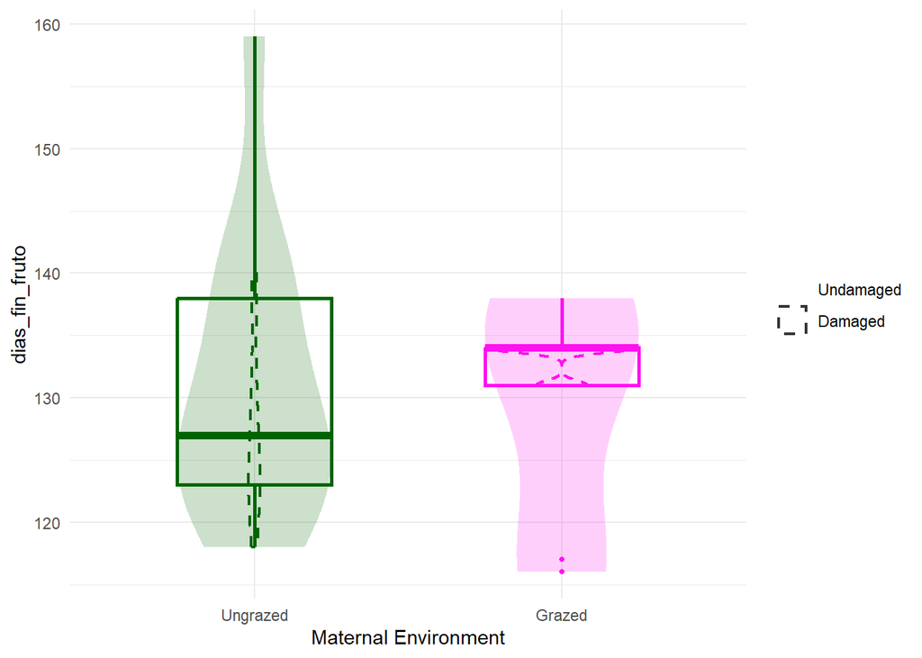